# Using clustering to find points in an image

Florian Privé

November 27, 2018

In this post, I present my new [package {img2coord}](https://github.com/privefl/img2coord). This package can be used to retrieve coordinates from a scatter plot (as an image).

```r
devtools::install_github("privefl/img2coord")
```

Have you ever made a plot, saved it as a png and moved on? When you come back to it, it is sometimes difficult to read the values from this plot, especially if there is no grid inside the plot.  
Making this package was also a good way to practice with clustering.

## A very simple example

### Saving a plot as PNG

```r
file <- tempfile(fileext = ".png")
png(file, width = 600, height = 400)
set.seed(1)
plot(c(0, runif(20), 1))
dev.off()
```

### Reading the PNG in R

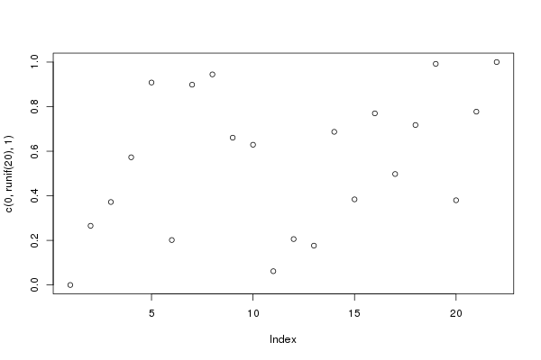

```r
(img <- magick::image_read(file))
```

### Get pixel indices from points

```r
## grayscale
img_mat <- img2coord:::img2mat(img)
dim(img_mat)
```

```
## [1] 400 600
```

```r
list.contour <- img2coord:::get_contours(img_mat)
img_mat_in <- img2coord:::get_inside(img_mat, list.contour)
dim(img_mat_in)
```

```
## [1] 264 507
```

```r
head(ind <- which(img_mat_in > 0, arr.ind = TRUE))
```

```
##      row col
## [1,] 256  14
## [2,] 257  14
## [3,] 254  15
## [4,] 255  15
## [5,] 256  15
## [6,] 257  15
```

### Cluster pixel indices

```r
set.seed(1)
km <- kmeans(ind, centers = 22)
```

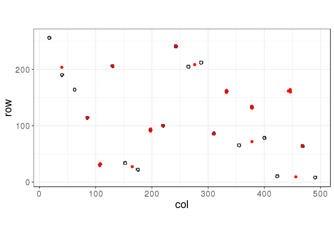

```r
library(ggplot2)
myplot <- function(points, centers) {
  p <- ggplot() +
    geom_tile(aes(col, row), data = as.data.frame(points)) +
    geom_point(aes(col, row), data = as.data.frame(centers), col = "red") +
    bigstatsr::theme_bigstatsr() +
    coord_equal()
  print(p)
}
myplot(ind, km$centers)
```

Even when using the true number of clusters, *kmeans* get trapped in a local minimum (this is clearly not the best solution!), depending on the initialisation of centers. One possible solution would be to use many initialisations; let’s try that.

```r
set.seed(1)
km <- kmeans(ind, centers = 22, nstart = 100, iter.max = 100)
```

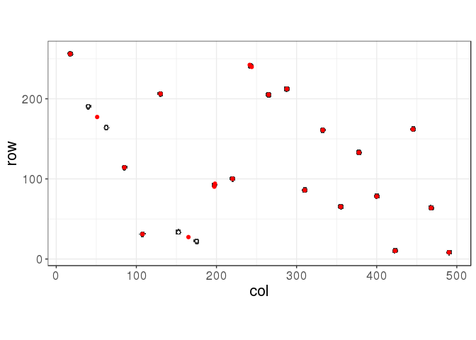

```r
myplot(ind, km$centers)
```

It is better but not optimal.

### Using hclust to get centers

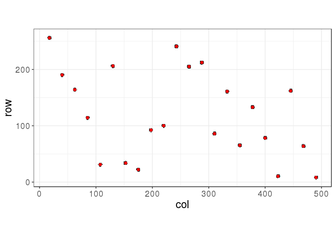

```r
get_centers <- function(points, clusters) {
  do.call("rbind", by(points, clusters, colMeans, simplify = FALSE))
}

d <- dist(ind)
hc <- hclust(d)
centers <- get_centers(ind, cutree(hc, k = 22))
myplot(ind, centers)
```

`hclust()` works well for this example.

### Get the number of clusters

What if we don’t know the number of clusters (representing the initial points)? A statistic that could help us determine the number of clusters to use is the silhouette.

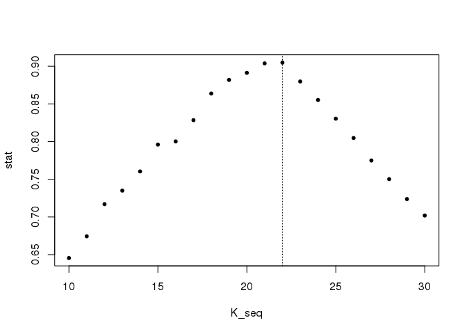

```r
K_seq <- seq(10, 30)
stat <- sapply(K_seq, function(k) {
  mean(cluster::silhouette(cutree(hc, k), d)[, 3])
})
plot(K_seq, stat, pch = 20); abline(v = 22, lty = 3)
```

## A less simple example

```r
file <- tempfile(fileext = ".png")
png(file, width = 600, height = 400)
set.seed(1)
y <- c(0, runif(100), 1)
plot(y, cex = runif(102, min = 0.5, max = 1.5))
dev.off()
```

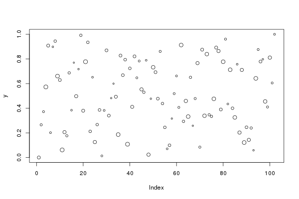

```r
(img <- magick::image_read(file))
```

```r
img_mat <- img2coord:::img2mat(img)
list.contour <- img2coord:::get_contours(img_mat)
img_mat_in <- img2coord:::get_inside(img_mat, list.contour)
ind <- which(img_mat_in > 0, arr.ind = TRUE)
```

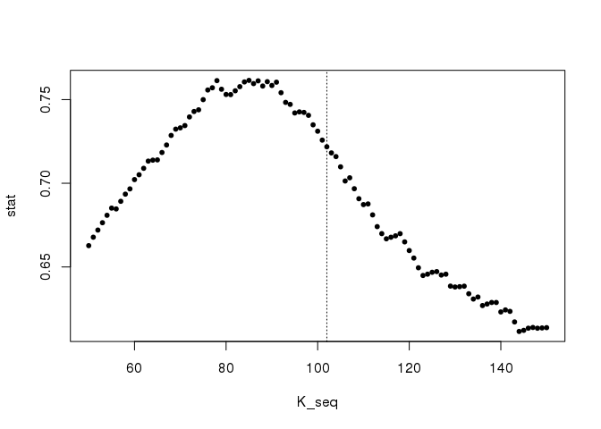

```r
hc <- flashClust::hclust(d <- dist(ind))
K_seq <- seq(50, 150)
stat <- sapply(K_seq, function(k) {
  mean(cluster::silhouette(cutree(hc, k), d)[, 3])
})
plot(K_seq, stat, pch = 20); abline(v = 102, lty = 3)
```

```r
(K_opt <- K_seq[which.max(stat)])
```

```
## [1] 85
```

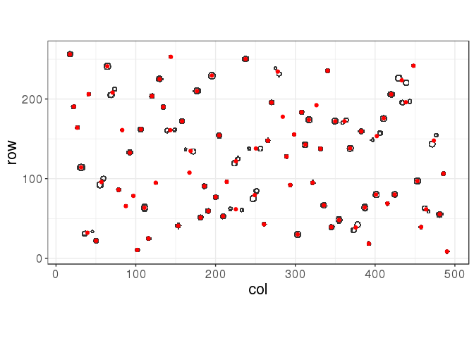

```r
centers <- get_centers(ind, cutree(hc, k = K_opt))
myplot(ind, centers)
```

The silhouette statistic is giving a good yet not optimal solution in this situation. Using the true number of points, we would get:

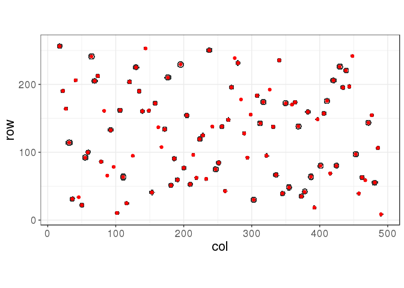

```r
centers <- get_centers(ind, cutree(hc, k = 102))
myplot(ind, centers)
```

If someone has a better statistic to (automatically) find the number of clusters, please share it and I’ll update this post.

## Putting everything together as a package

Finally, after you get the center of all points (pixel clusters), you can interpolate the values based on the values of axe ticks.

```r
coord <- img2coord::get_coord(
  file,
  x_ticks = seq(0, 100, 20),
  y_ticks = seq(0, 1, 0.2),
  K_min = 50, K_max = 150
)
```

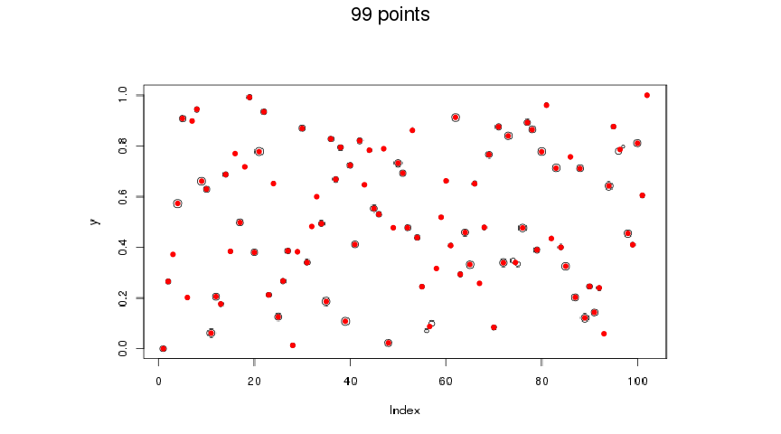

This works better here because I combined the silhouette statistic with a gini coefficient (measure of dispersion) of the number of pixels in each cluster (assuming that they should have approximately the same number). Let’s have a look at the combined statistic:

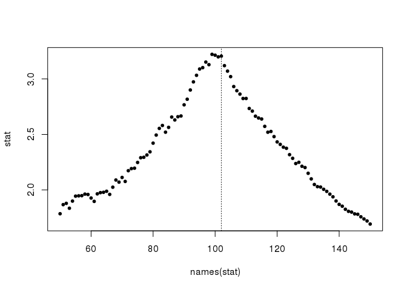

```r
stat <- attr(coord, "stat")
plot(names(stat), stat, pch = 20); abline(v = 102, lty = 3)
```

If you don’t get the right number of clusters the first time, you can use the plot generated by `img2coord::get_coord()` to adjust `K`.

```r
coord <- img2coord::get_coord(
  file,
  x_ticks = seq(0, 100, 20),
  y_ticks = seq(0, 1, 0.2),
  K = 102  ## 99 + 3
)
```

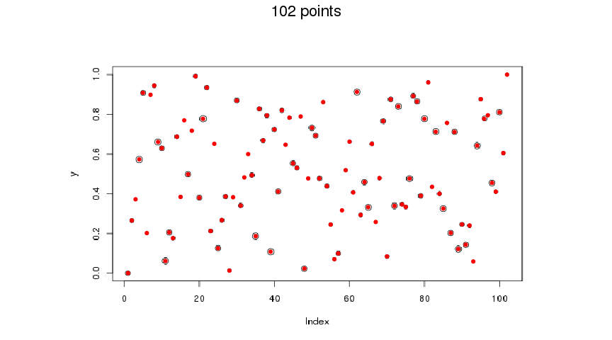

Let’s verify the coordinates we get:

```r
round(coord$x, 2)
```

```
##   [1]   1.00   2.01   3.01   4.00   4.99   6.01   7.00   8.00   9.01  10.01
##  [11]  10.98  11.99  12.99  14.01  15.00  15.98  17.01  18.00  18.98  20.00
##  [21]  20.99  22.00  23.00  23.99  24.98  26.00  26.99  28.01  29.00  29.98
##  [31]  31.01  31.99  33.02  34.00  35.02  35.98  37.00  38.01  38.99  40.00
##  [41]  40.99  41.99  42.99  44.01  44.97  45.98  47.01  48.00  49.00  50.00
##  [51]  51.01  51.98  52.99  53.99  55.00  56.00  57.01  58.01  59.00  60.02
##  [61]  61.00  62.00  62.98  64.01  64.99  65.98  67.00  68.01  68.98  70.00
##  [71]  70.98  72.00  73.00  74.01  75.00  76.01  77.00  78.00  79.02  79.98
##  [81]  81.00  82.01  82.98  84.00  85.01  85.99  87.01  87.98  88.99  89.99
##  [91]  90.98  92.00  93.00  94.01  95.00  95.89  96.87  97.99  99.00 100.00
## [101] 101.01 101.99
```

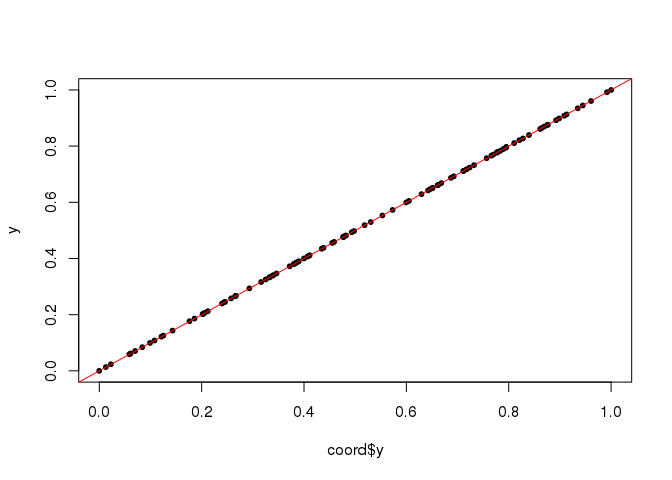

```r
plot(coord$y, y, pch = 20); abline(0, 1, col = "red")
```

## Handling large images

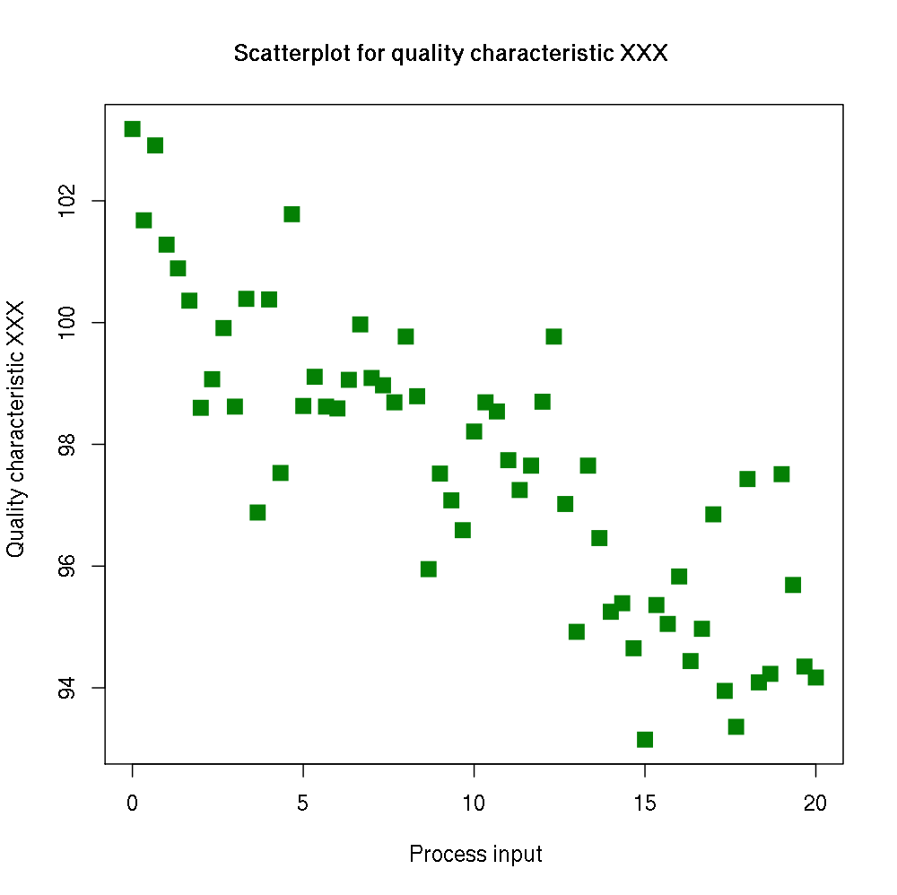

```r
url <- "https://goo.gl/K6Y7D1"
library(img2coord)
(img <- img_read(url))
```

```r
get_coord(img, seq(0, 20, 5), seq(94, 102, 2), K_min = 40, K_max = 80)
```

```
## Error: Detected more than 10000 pixels associated with points (21358).
##   Make sure you have a white background with no grid (only points).
##   You can change 'max_pixels', but it could become time/memory consuming.
##   You can also downsize the image using `img_scale()`.
```

The green points are spanning 21,358 pixels, which could be a lot to process, depending on your computer. To solve this problem, you can do:

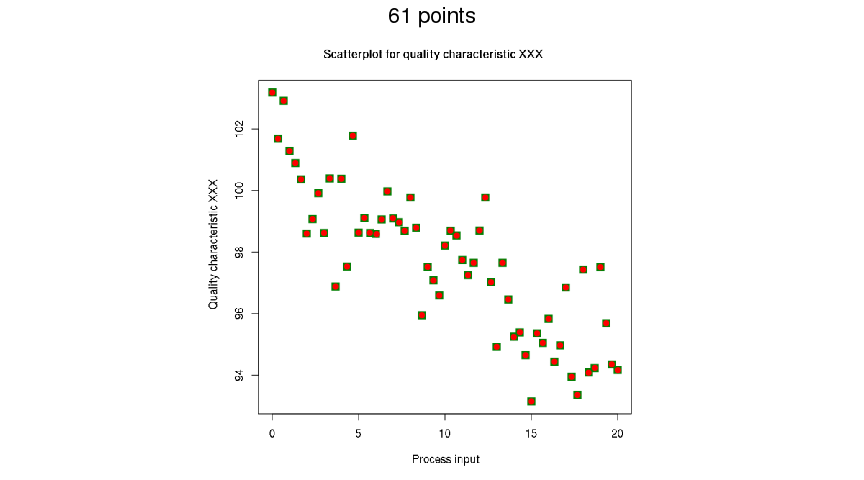

```
## $x
##  [1] -0.0005401687  0.3343468897  0.6664667098  0.9992303467  1.3337481120
##  [6]  1.6671560578  1.9997172265  2.3332269701  2.6674887594  2.9991939098
## [11]  3.3326859175  3.6672015650  4.0000566377  4.3329094030  4.6674459579
## [16]  5.0009192485  5.3326185095  5.6478368286  6.0464367945  6.3329501844
## [21]  6.6663573828  6.9839799351  7.3513525635  7.6674682785  8.0006621331
## [26]  8.3329974666  8.6657575234  8.9999189758  9.3339407034  9.6666009658
## [31] 10.0001231324 10.3173252500 10.6778169496 10.9989528978 11.3335964907
## [36] 11.6665738876 11.9994145980 12.3336165187 12.6676553366 12.9992455320
## [41] 13.3331964821 13.6668686496 13.9813979399 14.3425396058 14.6672323938
## [46] 15.0002253318 15.3330976683 15.6669750015 16.0007098735 16.3322818494
## [51] 16.6663301257 17.0005035442 17.3333809139 17.6663416006 18.0009680691
## [56] 18.3172429708 18.6798897677 18.9998067488 19.3333374006 19.6570288544
## [61] 20.0116006657
##
```

[output cut: 24 more lines]

```r
img %>%
 img_scale(0.4) %>%
 get_coord(seq(0, 20, 5), seq(94, 102, 2), K_min = 40, K_max = 80)
```

## Conclusion

Of course, this could be improved a lot. For example, this won’t work for plots having a background color or some grid inside. Feel free to bring your ideas. BTW, thanks [Robin](https://twitter.com/robincura) who brought some nice ideas that improved this package a lot.

Have a look at [the GitHub repo](https://github.com/privefl/img2coord).